# Statistik mit R für die Module W501, W873 und W662 (Teil I)

Betrachten wir ein Beispiel für das log-log Modell $\widehat {log(y)} = \widehat \beta_0 + \widehat \beta_1log(x)$. Wir nutzen die Daten für $P$ und $Q$ aus dem Datensatz oben:

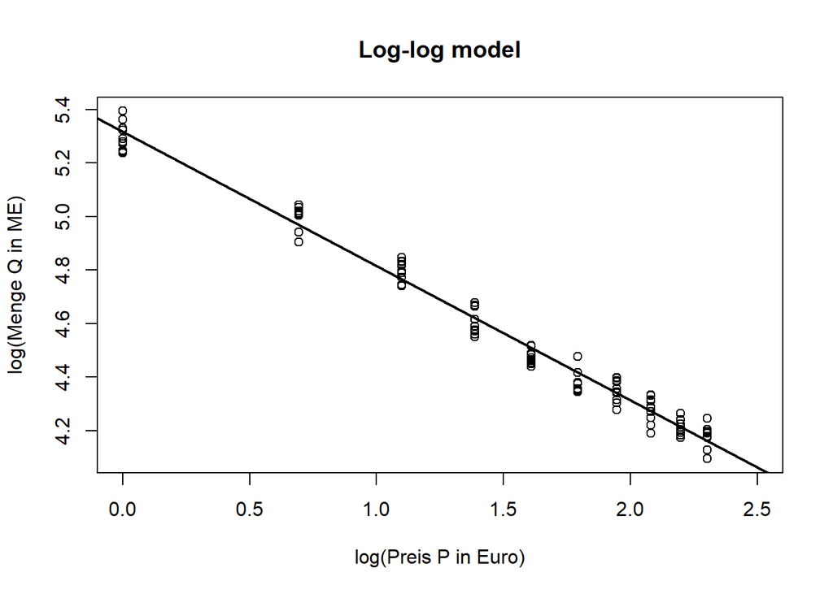

```r
plot(log(P), log(Q), xlab = "log(Preis P in Euro)", ylab = "log(Menge Q in ME)",
     main = "Log-log model", xlim = c(0, 2.5))
abline(lm(log(Q) ~ log(P)), lwd = 2)
```

In diesem Streudiagramm ist ein starker, negativer und linearer Zusammenhang zwischen den Logs zu erkennen.

Die Ausgabe der Modellparameter $\widehat \beta_0$ und $\widehat \beta_1$ erfolgt folgendermaßen:

```r
ols4 <- lm(log(Q) ~ log(P)); summary(ols4)
```

```
##
## Call:
## lm(formula = log(Q) ~ log(P))
##
## Residuals:
##      Min       1Q   Median       3Q      Max
## -0.08303 -0.04002  0.00443  0.04234  0.08360
##
## Coefficients:
##             Estimate Std. Error t value Pr(>|t|)
## (Intercept)   5.3172     0.0113   470.5   <2e-16 ***
## log(P)       -0.5023     0.0068   -73.9   <2e-16 ***
## ---
## Signif. codes:  0 '***' 0.001 '**' 0.01 '*' 0.05 '.' 0.1 ' ' 1
##
## Residual standard error: 0.0473 on 98 degrees of freedom
## Multiple R-squared:  0.982,  Adjusted R-squared:  0.982
## F-statistic: 5.46e+03 on 1 and 98 DF,  p-value: <2e-16
```

Der Anstiegsparameter im log-log Modell kann als konstante **Elastizität** interpretiert werden. Hier: Steigt der Preis um 1%, dann reduziert sich gemäß der Modellprognose die Menge um 0.5%. Es liegt eine unelastische Nachfrage vor. Analog erfolgt die Berechnung für Einkommenselastizitäten, Kreuzpreiselastizitäten usw.

Betrachten wir das Streudiagramm zwischen $E$ und $\widehat Y$.

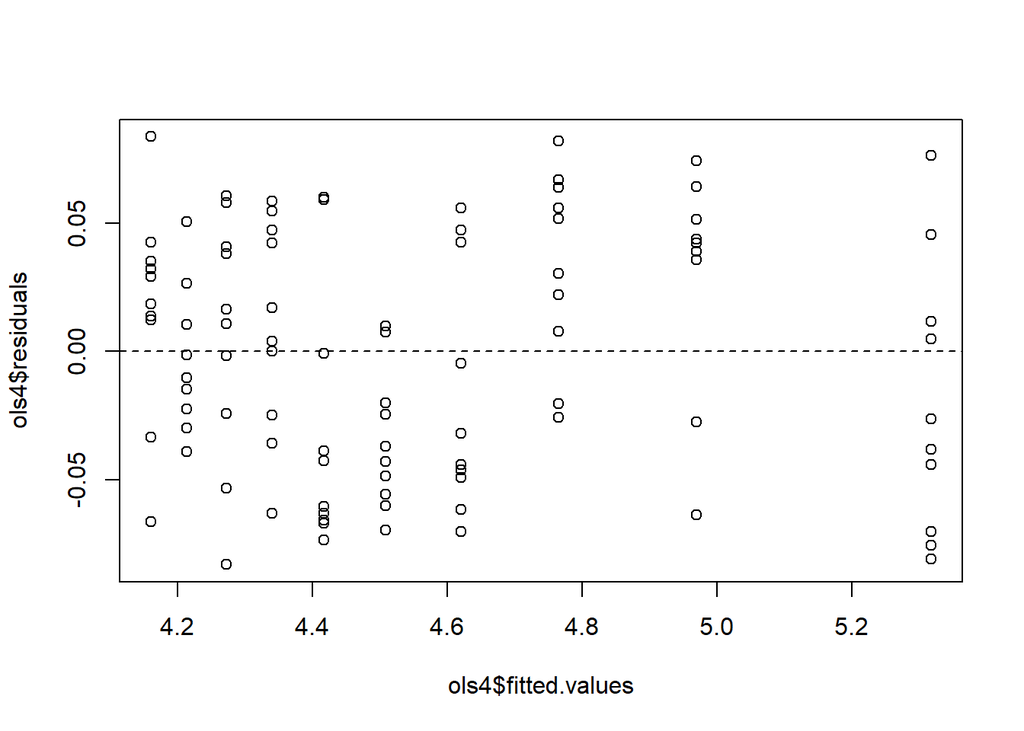

```r
plot(ols4$fitted.values, ols4$residuals)
abline(h = 0, lty = 2)
```

Die Verteilung der Werte ist relativ unauffällig (zumindest aber besser als vor der Transformation). Die Normalverteilungsannahme muss verworfen werden (die Stichprobe ist aber hinreichend groß, daher ist dies unproblematisch).

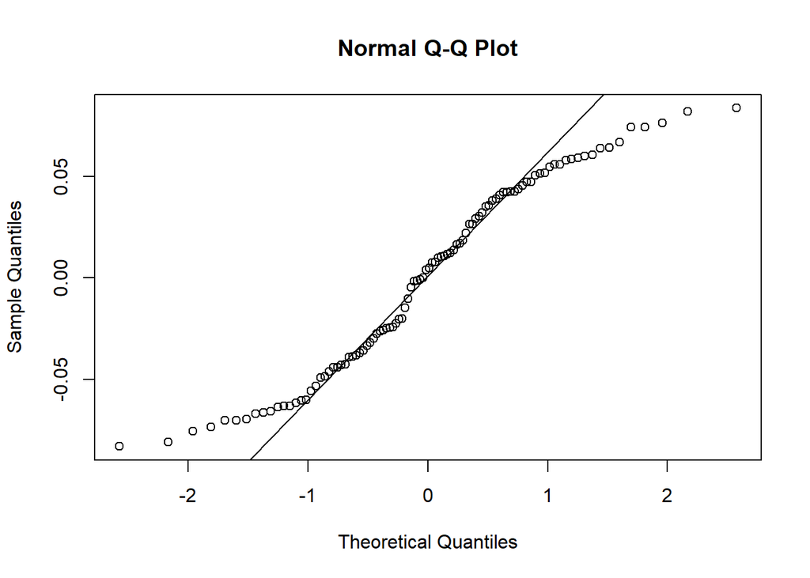

```r
qqnorm(ols4$residuals)          # qq-Plot
qqline(ols4$residuals)          # mit Linie
```

```r
shapiro.test(ols4$residuals)    # verwerfe Normalverteilung
```

```
##
##  Shapiro-Wilk normality test
##
## data:  ols4$residuals
## W = 0.949, p-value = 0.00076
```

```r
cor(log(Q), log(P), method = "pearson")^2
```

```
## [1] 0.98238
```

Das $R^2$ ist relativ hoch mit 98%. Interpretation: Der natürliche Log von $P$ kann 98% der Streuung des natürlichen Logs von $Q$ erklären.

Die Rücktransformation und grafische Darstellung im Plot für $P$ und $Q$ erfolgt folgendermaßen:

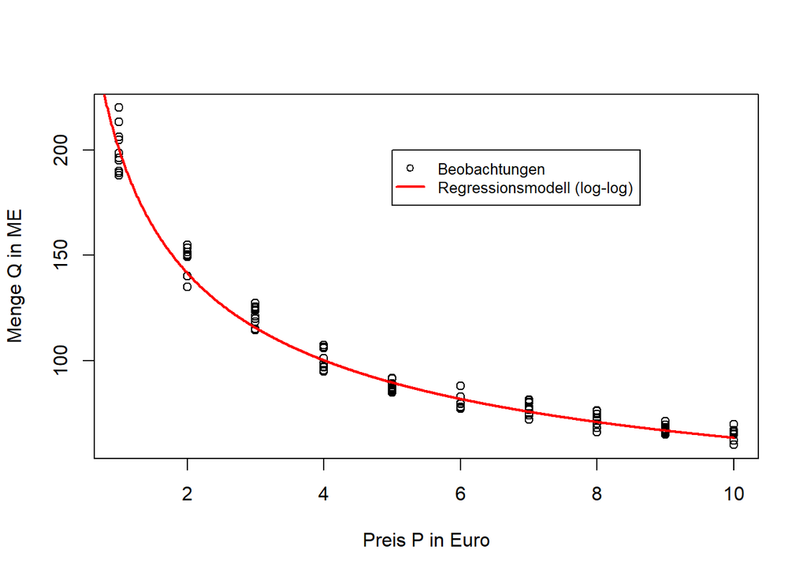

```r
P_ols <- seq(0, 10, 0.01)
Q_ols <- 2.718^(5.3 - 0.5*log(P_ols))
plot(P, Q, ylab = "Menge Q in ME", xlab = "Preis P in Euro")
lines(P_ols, Q_ols, lwd = 2, col = "red")
legend(5, 200, pch = c(1,NA), c("Beobachtungen","Regressionsmodell (log-log)"), lwd = c(NA,2),
col = c("black","red"), cex = 0.8)
```

### Exkurs: Konfidenz- und Vorhersageintervalle

Unsere Schätzung der wahren Regressionsgeraden in der Grundgesamtheit basiert auf Stichprobeninformationen und ist daher unsicher. Wir können aber die Unsicherheit quantifizieren mit Hilfe von Intervallaussagen. Bei der Prognose von y-Werten durch eine Regression gilt es dabei zwei Fälle zu unterscheiden:

1. Man will den mittleren y-Wert prognostizieren. In diesem Fall spricht man von einem **Konfidenzintervall** (confidence interval).
2. Man will einen einzelnen y-Wert prognostizieren. In diesem Fall spricht man von einem **Vorhersageintervall** (prediction interval).

Ausgangspunkt ist ein Wert für die unabhängige Variable $X$, bezeichnet mit $x_v$. Das geschätzte lineare Modell prognostiziert für $x_v$ den Wert $\widehat{y}_v={\beta}_0 + {\beta}_1x$.

Die gemeinsame Formel für beide Intervalle ist:

$(1-\alpha)$-Intervall $= \widehat{y}_v \pm t^*_{[1-\alpha]n-2}SE$

Beide Intervalle sind also zentriert um $\widehat{y}_v$ und unterscheiden sich demnach in ihren Standardfehlern ($SE$), also der Streuung der Werte.

#### Konfidenzintervall für den mittleren Wert

Die Formel für das Konfidenzintervall für den mittleren Wert ist:

$(1-\alpha)$-Intervall $= \widehat{y}_v \pm t^*_{[1-\alpha]n-2}SE$

mit

$SE(\widehat\mu_v)=\sqrt{SE(\beta_1)^2(x_v-\bar{x})^2+\frac{\widehat \sigma_e^2}{n}}$

Der Standardfehler, d.h. die Streuung des vorhergesagten mittleren Wertes, und damit die Breite des Konfidenzintervalls wird durch drei Größen beeinflusst:

1. Das KI wird breiter (unsere Schätzung wird also unsicherer), je weiter man sich vom mittleren x-Wert entfernt. Dies ist der Term $(x_v-\bar{x})^2$ in der Formel für den $SE$.
2. Wie alle KIs variiert die Breite des Intervalls auch mit der Zahl der Beobachtungen. Eine größeres $n$ generiert ein schmaleres KI und damit eine präzisere Vorhersage.
3. Der Streuung der Beobachtung um die Regressionsgerade, gemessen durch $\widehat \sigma_e$, beeinflusst ebenfalls die Breite des KI. Wenn es eine größere Streuung der Werte um die Regressionsgerade gibt, ist die Vorhersage unsicherer und unser KI breiter.

#### Vorhersageintervall für einen individuellen Wert

Die Formel für das Vorhersageintervall für einen individuellen Wert ist:

$(1-\alpha)$-Intervall $= \widehat{y}_v \pm t^*_{[1-\alpha]n-2}SE$

mit

$SE(\widehat{y}_v)=\sqrt{SE(\beta_1)^2(x_v-\bar{x})^2+\frac{\widehat \sigma_e^2}{n} + \widehat \sigma_e^2}$

Die größere Streuung dieses Intervalls drückt sich dadurch aus, dass in der Summe der Varianzen (unter der Quadratwurzel) noch die Varianz der Residuen ($\widehat \sigma_e^2$) hinzuaddiert wird.

Betrachten wir Bsp. 5.2 aus dem Lehrbuch.

```r
setwd("C:/Users/sturm/Desktop/dataR")   # setze das Arbeitsverzeichnis
data <- read.csv("Bsp._5.2.csv")
# data <- read.csv("https://raw.githubusercontent.com/bodosturm/dataR/main/Bsp._5.2.csv")
attach(data); names(data)
```

```
## [1] "output"    "totalcost"
```

```r
ols <- lm(totalcost ~ output)
```

Die Ausgabe des 95%-Konfidenzintervalls für die Regressionsgerade erfolgt mit `predict()` und der Angabe `int = 'c'`.

```r
predict(ols, int = "c")[1:3, ] # Gebe die ersten 3 Werte des KI aus.
```

```
##      fit    lwr    upr
## 1 23.508 21.469 25.547
## 2 24.400 22.705 26.095
## 3 25.293 23.894 26.691
```

Die Ausgabe des 95%-Vorhersageintervalls für die y-Beobachtungen erfolgt entsprechend mit `int = 'p'`.

```r
predict(ols, int = "p")[1:3, ] # Gebe die ersten 3 Werte des Intervalls aus.
```

```
##      fit    lwr    upr
## 1 23.508 18.393 28.623
## 2 24.400 19.413 29.388
## 3 25.293 20.398 30.188
```

Das 95%-KI ist - wie zu erwarten - deutlich schmaler das das 95%-Vorhersageintervall.

Der Plot der Intervalle erfordert etwas Arbeit. Wir erstellen hierfür einen neuen data frame (also eine Datentabelle), in dem wir die Vorhersagen bzw. Bänder (untere und obere Grenzen) abspeichern. Dann nutzen wir mit `matlines()` einen neuen Befehl, der es gestattet, die Spalten einer Matrix gegen einen Vektor zu plotten (`lines()` kann nur Vektor gegen Vektor plotten).

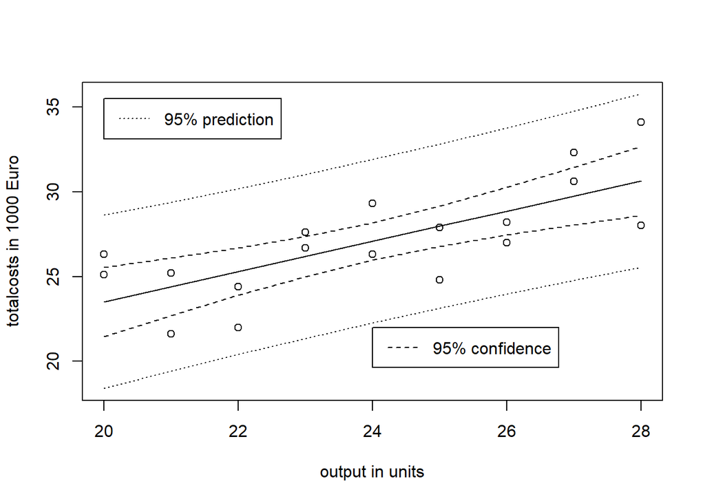

```r
pred.frame <- data.frame(output = 20:28) # Begrenze die Ausgabe
pc <- predict(ols, int = "c", newdata=pred.frame)
pp <- predict(ols, int = "p", newdata=pred.frame)
pred.out <- pred.frame$output
plot(output, totalcost, xlab = "output in units", ylab = "totalcosts in 1000 Euro",
ylim = range(totalcost, pp))
matlines(pred.out, pc, lty = c(1,2,2), col = "black")
matlines(pred.out, pp, lty = c(1,3,3), col = "black")
legend(24, 22, lty = 2, "95% confidence")
legend(20, 35.5, lty = 3, "95% prediction")
```

In der Abbildung ist gut zu erkennen, dass das Vorhersageintervall für einen einzelnen Wert deutlich breiter ist als das Konfidenzintervall für den wahren Mittelwert. Das macht intuitiv Sinn: Es ist viel unsicherer (<=> Breite des Intervalls) einen bestimmten $y$-Wert gegeben $x$ vorherzusagen, als eine Prognose über die Lage des wahren Mittelwerts $\bar y$ gegeben $x$ zu treffen (hier greift der Zentrale Grenzwertsatz mit größerem $n$). Auch gut zu erkennen: Je weiter man sich vom arithmetischen Mittel von $X$ entfernt, desto größer wird $SE$ und damit auch das Intervall.

### Inferenz für Korrelation

Wir betrachten hier den Pearson-Korrelationskoeffizienten für quantitative Daten und den Spearman-Rang-Korrelationskoeffizienten für qualitative Daten mit ordinaler Skalierung. Beide Korrelationskoeffizienten sind Maße für die Effektgröße (<=> ökonomische Signifikanz). Hier wird jetzt untersucht, ob die Korrelation auch statistisch signifikant ist.

#### Pearson-Korrelation

Es sei $\rho$ die wahre aber unbekannte Korrelation in der Grundgesamtheit.

Wir testen:

$H_0: \rho = 0$ vs. $H_A: \rho \neq 0$

Der Korrelationskoeffizient $r$ in einer Stichprobe ist die Realisation der Zufallsvariablen $R$.

Unter bestimmten Annahmen (den Annahmen der Einfachregression) gilt:

$R\sqrt{\frac{n-2}{1-R^2}} \sim T_{df}$ mit $df = n - 2$

und wir können diesen Term als Testvariable nutzen. Wir können dann die Realisation der Testvariablen, $r\sqrt{\frac{n-2}{1-r^2}}$, zur Berechnung eines p-values verwenden.

Eigentlich ist der Test auf Korrelation redundant, denn es gilt:

$\beta_1 = r\frac{\sigma_Y}{\sigma_X}$

Wenn wir also für $\beta_1$ testen, ist das schon der Test für $\rho$ (also für die wahre Korrelation in der Grundgesamtheit). Dennoch testet man manchmal die Korrelation separat, wenn keine Regression benötigt wird.

Das Problem: Die Berechnung eines KI für Pearson’s $\rho$ ist etwas umständlicher als im Fall des KIs für den Mittelwert $\mu$ einer Grundgesamtheit. Dies liegt daran, dass $\rho$ im Intervall [-1,1] definiert ist. Liegt z.B. eine Korrelation 0.95 vor, so kann die Korrelation in der Grundgesamtheit nicht größer als 1 sein, aber durchaus deutlich kleiner als 0.9 und daher ist das Intervall für $\rho$ nicht symmetrisch um $r$.

Basis für das KI ist die sog. “Fisher-Transformation”.

$z = \frac{1}{2}ln(\frac{1+\rho}{1-\rho})$ mit $\rho$ als Korrelation in der Grundgesamtheit

Es gilt:

$z \sim N(\mu, s)$

mit

$E(z) = \mu = \frac{1}{2}ln(\frac{1+\rho}{1-\rho})$

mit $\rho$ als Korrelation in der Grundgesamtheit, die mit $r$ geschätzt wird, und

$s(z) = \sqrt{\frac{1}{n-3}}$

Wir können also einen z-Wert aus dem in der Stichprobe beobachteten $r$ berechnen. Mit diesem z-Wert aus der Stichprobe kann dann das KI für den wahren aber unbekannten z-Wert in der Grundgesamtheit ($z_{GG}$) bestimmt werden mit

$KI(1-\alpha)_{z_{GG}} = z \pm z_{[1-\alpha/2]}s(z)$

Die Grenzen des KI für $z_{GG}$ können wiederum transformiert werden mit

$z = \frac{1}{2}ln(\frac{1+r}{1-r}) \iff e^{2z} = \frac{1+r}{1-r}$

$\iff r = \frac{e^2z - 1}{e^2z + 1}$

Betrachten wir das Beispiel 4.3 aus dem Lehrbuch.

```r
gewicht <- c(60,76,60,75,66,65,78,75,87,72,90,82,92)
groesse <- c(170,172,175,176,177,180,180,183,185,187,188,190,194)
cor.test(gewicht, groesse, method = "pearson")
```

```
##
##  Pearson's product-moment correlation
##
## data:  gewicht and groesse
## t = 3.9, df = 11, p-value = 0.0025
## alternative hypothesis: true correlation is not equal to 0
## 95 percent confidence interval:
##  0.36381 0.92475
## sample estimates:
##     cor
## 0.76204
```

Die Berechnung per Hand ergibt:

```r
n <- length(gewicht)
r <- cor(gewicht, groesse, method = "pearson"); r
```

```
## [1] 0.76204
```

```r
t <- r*sqrt((n-2)/(1-r^2)); t
```

```
## [1] 3.9032
```

Das 95%-KI bestimmt sich über die Fisher-Transformation:

```r
z <- 0.5*log((1+r)/(1-r)); z    # Fisher Transformation
```

```
## [1] 1.0011
```

```r
s <- sqrt(1/(n-3)); s           # Standardabweichung von z
```

```
## [1] 0.31623
```

```r
mu <- 0.5*log((1+r)/(1-r)); mu  # E(z)
```

```
## [1] 1.0011
```

```r
CI_up_z <- z + qnorm(0.975)*s; CI_up_z      # upper limit in z
```

```
## [1] 1.6209
```

```r
CI_low_z <- z - qnorm(0.975)*s; CI_low_z    # lower limit in z
```

```
## [1] 0.38128
```

```r
e <- exp(1); e                              # Eulersche Zahl
```

```
## [1] 2.7183
```

```r
CI_up <- (e^(2*CI_up_z) - 1)/(e^(2*CI_up_z) + 1); CI_up
```

```
## [1] 0.92475
```

```r
CI_low <- (e^(2*CI_low_z) - 1)/(e^(2*CI_low_z) + 1); CI_low
```

```
## [1] 0.36381
```

Es geht zum Glück auch etwas einfacher:

```r
library(mada) # Paket "mada" muss installiert sein
CIrho(0.7620432, n, level = 0.95)
```

```
##          rho   2.5 %  97.5 %
## [1,] 0.76204 0.36381 0.92475
```

#### Spearman-Rang-Korrelation

Die Überlegungen oben zu Pearson gelten hier entsprechend. Es sei $\rho_{Sp}$ die wahre aber unbekannte Spearman-Korrelation in der Grundgesamtheit.

Wir testen:

$H_0: \rho^{Sp} = 0$ vs. $H_A: \rho^{Sp} \neq 0$

Wenn $n > 10$ gilt approximativ:

$R^{Sp}\sqrt{\frac{n - 2}{1 - (R^{Sp})^2}} \sim T_{df}$ mit $df = n - 2$

Der Korrelationskoeffizient $r^{Sp}$ ist die Realisation der Zufallsvariablen $R^{Sp}$.

Wir können dann $r^{Sp}\sqrt{\frac{n - 2}{1 - (r^{Sp})^2}}$ zur Berechnung eines p-values nutzen.

Betrachten wir Beispiel 4.4 im Lehrbuch.

```r
M <- c(1.3, 4, 5, 2.3, 1, 1.7, 1, 3, 3.7, 2.7, 2.0)
S <- c(2 , 3.7, 3.3, 2.7, 1.3, 1, 1.7, 2.3, 3, 3, 4.0)
cor.test(M, S, method = "spearman", exact = FALSE)
```

```
##
##  Spearman's rank correlation rho
##
## data:  M and S
## S = 64.3, p-value = 0.015
## alternative hypothesis: true rho is not equal to 0
## sample estimates:
##     rho
## 0.70776
```

Die Prüfgröße `S` (berechnet über MW-U Test, vgl. Lehrbuch) wird hier nicht betrachtet.

```r
r_Sp <- 0.7077626; r_Sp
```

```
## [1] 0.70776
```

```r
n <- 11
t <- r_Sp*sqrt((n-2)/(1-r_Sp^2)); t
```

```
## [1] 3.0056
```

```r
p_value <- 2*(1 - pt(t, n-2)); p_value
```

```
## [1] 0.014822
```